# Board_Games_Regression_Project

Adrian Homero Moreno García- adrian.moreno@iteso.mx, Gabriel Alejandro Morales Ruiz-

6/21/2021

[figure not shown]

## Introducción

José es un diseñador de juegos de mesa. Crea las reglas, diseña los gráficos, escoge su tema, número de jugadores y duración promedio del juego que tiene en mente. José es una persona tímida, y a pesar de que sus juegos suelen gustarle a sus amigos, él nunca ha querido publicarlos por miedo a que no sean bien recibidos. Se quiere demostrar a José, con una base de datos de calificaciones históricas de juegos de mesa, cómo hubieran sido recibidos sus juegos en promedio en la época que los fue creando.

Los datos a utilizar vienen de esta base de datos: [(board_games)](https://github.com/rfordatascience/tidytuesday/tree/master/data/2019/2019-03-12)* que, en cambio, vienen de la página Board Game Geek.

## Instalación de Paquetes

Procedemos para empezar en instalar los siguientes paquetes, se puede omitir este paso si ya se tienen previamente instalados. Aquí una lista de los cuales vamos a necesitar.

```r
install.packages("lares")
```

## Cargar Librerías

Usando ‘library’ cargamos las librerías, con las cuales vas a hacer uso de las diferentes funciones.

```r
library("DataExplorer")
library(lares)
```

## Ánalisis Descriptivo, Data Engineering

### Observación de las primeras líneas

- game_id Identificador único
- description Descripción corta
- image URL con imagen del juego
- max_players Jugadores máximos
- max_playtime Tiempo máximo de juego
- min_age Edad mínima
- min_players Jugadores mínimos
- min_playtime Tiempo mínimo de juego
- name Nombre del juego
- playing_time Tiempo promedio de juego
- thumbnail URL con thumbnail del juego
- year_published Año de publicación
- artist Diseñador gráfico del juego
- category Categorías del juego (separadas por coma)
- compilation Si es parte de una compilación, nombre de la compilación
- designer Diseñador del juego
- expansion Si hay una expansión, el nombre de la expansión
- family Familia, equivalente a editora
- mechanic Mecánicas, separadas por coma
- publisher Compañía o persona que publicaron el juego (separadas por coma)
- average_rating Calificación promedio en Board Game Geek
- users_rated Número de usuarios que calificaron el juego

|  | game_id | description | image | max_players | max_playtime | min_age | min_players | min_playtime | name | playing_time | thumbnail | year_published | artist | category | compilation | designer | expansion | family | mechanic | publisher | average_rating | users_rated |
| --- | --- | --- | --- | --- | --- | --- | --- | --- | --- | --- | --- | --- | --- | --- | --- | --- | --- | --- | --- | --- | --- | --- |
| 1 | 1 | Die Macher is a game about seven sequential political races in different regions of Germany. Players are in charge of national political parties, and must manage limited resources to help their party … | //cf.geekdo-images.com/images/pic159509.jpg | 5 | 240 | 14 | 3 | 240 | Die Macher | 240 | //cf.geekdo-images.com/images/pic159509_t.jpg | 1986 | Marcus Gschwendtner | Economic,Negotiation,Political | NA | Karl-Heinz Schmiel | NA | Country: Germany,Valley Games Classic Line | Area Control / Area Influence,Auction/Bidding,Dice Rolling,Hand Management,Simultaneous Action Selection | Hans im Glück Verlags-GmbH,Moskito Spiele,Valley Games, Inc. | 7.66508 | 4498 |
| 2 | 2 | Dragonmaster is a trick-taking card game based on an older game called Coup d'etat. Each player is given a supply of plastic gems, which represent points. Each player will get to be the dealer for fiv… | //cf.geekdo-images.com/images/pic184174.jpg | 4 | 30 | 12 | 3 | 30 | Dragonmaster | 30 | //cf.geekdo-images.com/images/pic184174_t.jpg | 1981 | Bob Pepper | Card Game,Fantasy | NA | G. W. "Jerry" D'Arcey | NA | Animals: Dragons | Trick-taking | E.S. Lowe,Milton Bradley | 6.60815 | 478 |
| 3 | 3 | Part of the Knizia tile-laying trilogy, Samurai is set in medieval Japan. Players compete to gain the favor of three factions: samurai, peasants, and priests, which are represented by helmet, rice pad… | //cf.geekdo-images.com/images/pic3211873.jpg | 4 | 60 | 10 | 2 | 30 | Samurai | 60 | //cf.geekdo-images.com/images/pic3211873_t.jpg | 1998 | Franz Vohwinkel | Abstract Strategy,Medieval | NA | Reiner Knizia | NA | Asian Theme,Country: Japan,Knizia tile-laying trilogy,Samurai | Area Control / Area Influence,Hand Management,Set Collection,Tile Placement | 999 Games,ABACUSSPIELE,Astrel Games,Ceilikan Jogos,Descartes Editeur,Edge Entertainment,Fantasy Flight Games,Galakta,Hans im Glück Verlags-GmbH,Hobby Japan,Lacerta,Lautapelit.fi,Rio Grande Games,Skan… | 7.44119 | 12019 |
| 4 | 4 | When you see the triangular box and the luxurious, large blocks, you can tell this game was designed to be beautiful as well as functional. The object of the game is to build pyramids out of the diffe… | //cf.geekdo-images.com/images/pic285299.jpg | 4 | 60 | 12 | 2 | 60 | Tal der Könige | 60 | //cf.geekdo-images.com/images/pic285299_t.jpg | 1992 | NA | Ancient | NA | Christian Beierer | NA | Country: Egypt,Promotional Board Games | Action Point Allowance System,Area Control / Area Influence,Auction/Bidding,Set Collection | KOSMOS | 6.60675 | 314 |
| 5 | 5 | In Acquire, each player strategically invests in businesses, trying to retain a majority of stock. As the businesses grow with tile placements, they also start merging, giving the majority stockholder… | //cf.geekdo-images.com/images/pic342163.jpg | 6 | 90 | 12 | 3 | 90 | Acquire | 90 | //cf.geekdo-images.com/images/pic342163_t.jpg | 1964 | Scott Okumura,Peter Whitley | Economic | NA | Sid Sackson | NA | 3M Bookshelf Series | Hand Management,Stock Holding,Tile Placement | 3M,Avalon Hill,Avalon Hill (Hasbro),Dujardin,Grow Jogos e Brinquedos,PS-Games,Schmidt France,Schmidt International,Schmidt Spiele,Selecta Spel en Hobby,Smart Games, Inc. | 7.35830 | 15195 |
| 6 | 6 | In the ancient lands along the Mediterranean, players attempt to satisfy their unique victory conditions via trade, war and construction. This lavishly produced game contains tons of wooden game compo… | //cf.geekdo-images.com/images/pic28424.jpg | 6 | 240 | 12 | 2 | 240 | Mare Mediterraneum | 240 | //cf.geekdo-images.com/images/pic28424_t.jpg | 1989 | Jean du Poël | Civilization,Nautical | NA | Jean du Poël | NA | Cities: Marseille | Dice Rolling | Historien Spiele Galerie (Historien Spielegalerie) | 6.52534 | 73 |

### Colnames de nuestro dataset

Después de una rápida observación, ejecutamos los siguientes comandos para confirmación:

```r
colnames(board_games)
```

```
 [1] "game_id"        "description"    "image"          "max_players"    "max_playtime"
 [6] "min_age"        "min_players"    "min_playtime"   "name"           "playing_time"
[11] "thumbnail"      "year_published" "artist"         "category"       "compilation"
[16] "designer"       "expansion"      "family"         "mechanic"       "publisher"
[21] "average_rating" "users_rated"
```

### Tipo de variables

Usando data explorer observamos el tipo de variables, casi tenemos el mismo porcentaje para las discretas y continua, y tenemos un bajo porcentaje de missing values:

Estos valores faltantes nos podrán general problemas para analizar los datos, veamos un poco los perfiles que faltan.

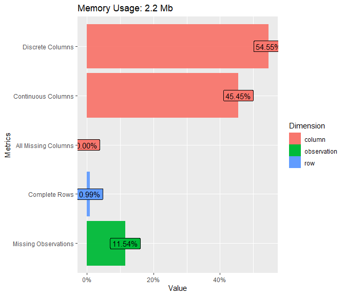

### Missing plot

Para visualizar el perfil de los datos faltantes podemos utilizar la función plot_missing(). En la visualización debajo, podemos ver que la variables compilation y expansion, son las que les falta información, encontramos de que sólo el 2.63% (compilation), 16.54% (expansion) de nuestras filas estén completas y probablemente esta varible no sea de mucha infomación. Por tanto la podemos eliminar de nuestro dataframe, ahorita mismo!!

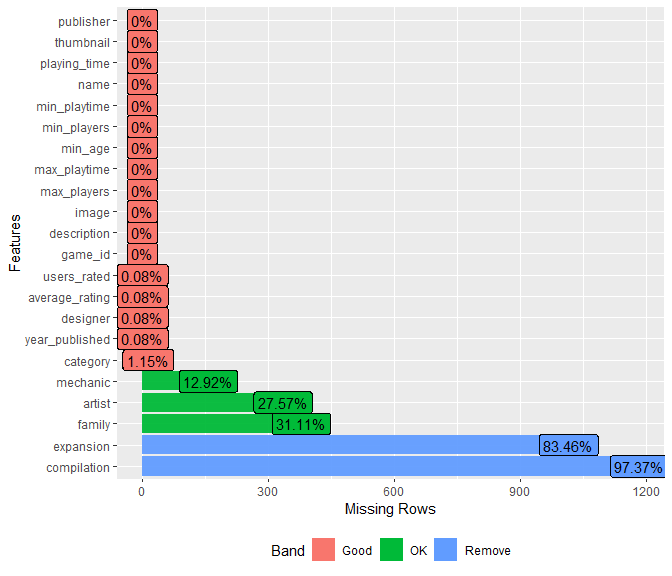

### Eliminamos la columna que tienes más missing values

```r
final_board_games <- drop_columns(board_games, c("compilation","expansion"))

colnames(final_board_games)
```

```
 [1] "game_id"        "description"    "image"          "max_players"    "max_playtime"
 [6] "min_age"        "min_players"    "min_playtime"   "name"           "playing_time"
[11] "thumbnail"      "year_published" "artist"         "category"       "designer"
[16] "family"         "mechanic"       "publisher"      "average_rating" "users_rated"
```

### Ánalisis de Correlación

Podemos ver la más alta correlación en estas variables:

```
Ignored all discrete features since `maxcat` set to 5 categories!
```

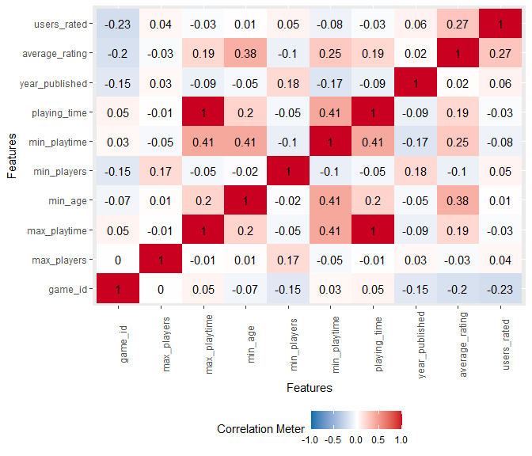

```r
plot_correlation(na.omit(final_board_games), maxcat = 5L)
```

Ahora de una manera más detallada vamos a analizar las variables más correlacionadas entre si, este top de 10:

```
Returning only the top 10. You may override with the 'top' argument
`guides(<scale> = FALSE)` is deprecated. Please use `guides(<scale> = "none")` instead.
```

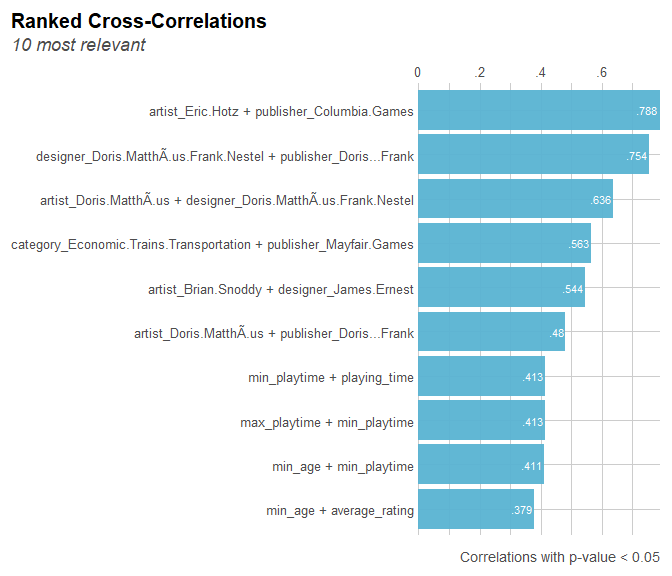

```r
corr_cross(final_board_games, # name of dataset
  max_pvalue = 0.05, # display only significant correlations (at 5% level)
  top = 10 # display top 10 couples of variables (by correlation coefficient)
)
```

### QQ plot

La gráfica Quantile-Quantile es una forma de visualizar la desvisión de una distribución de probabilidad específica.

Después de analizar estos gráficos, a menudo es beneficioso aplicar una transformación matemática (como logaritmo) para modelos como la regresión lineal. Para hacerlo, podemos usar la función plot_qq. De forma predeterminada, se compara con la distribución normal.

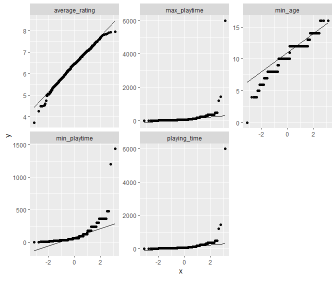

En el gráfico, las columnas parecen sesgadas en ambas colas. Apliquemos una transformación logarítmica simple y grafiquemos de nuevo. Average Rating no mejoró. Gabo si ves que es necesario podemos hacerle update a las columnas con la transformación.

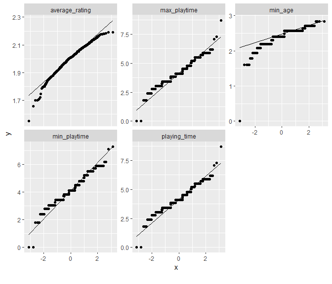